# Welcome to Medical Statistics

- ✔️ Find a seat and check in with the persons sitting next to you
- ✔️ If you haven’t prepared R and RStudio, find somebody who did that you can sit next to.
- ✔️ Check out the website https://danmazjen.github.io/medicinsk-statistik/

## Before we start the session today…

## Mac users

In you Terminal, run:

```bash
xcode-select --install
```

You need this to install the `{medisr}` package

*This as been added to the website installation guide*

## 🙋‍♀️ do you have R & RStudio?

## Why Medical statistics?

## Why Medical statistics?

[figure not shown]

Reason 1

## Why Medical statistics?

[figure not shown]

Reason 2

Medical science  
and clinical practice

depends on  
→

Medical statistics

Medical science  
and clinical practice

depends on  
→  
←  
informed by

Medical statistics

## Jobs that emphasize statistical literacy

| Branch | Job | Statistical literacy needed? |
| --- | --- | --- |
| 🧬 **Biomedicine** | Research Scientist | **High** |
|  | Biomedical Researcher | **High** |
|  | Biomarker Scientist | **High** |
|  | Clinical/Preclinical Researcher | **High** |
|  | Bioinformatics Scientist | **Very high** |
|  | Diagnostics Development Scientist | **Moderate–high** |
|  | Laboratory Scientist | **Moderate** |
|  | Quality Control Specialist | **Moderate** |
|  | Quality Assurance Specialist | **Moderate** |
|  | Laboratory Operations Coordinator | **Low** |
| 💊 **Translational Medicine** | Clinical Research Scientist | **High** |
|  | Clinical Research Associate (CRA) | **Moderate** |
|  | Clinical Trial Coordinator | **High** |
|  | Clinical Data Scientist | **Very high** |
|  | Drug Development Scientist | **High** |
|  | Pharmacovigilance Scientist | **High** |
|  | Medical Researcher | **Very-High** |
|  | Regulatory Affairs Specialist | **Moderate-High** |
|  | Clinical Operations Specialist | **Low–moderate** |
|  | Clinical Project Coordinator | **Moderate** |
|  | Medical Affairs | **Low–moderate** |
|  | Quality/Compliance | **Low** |
| 📊 **Medical Market Access** | Health Economist | **Very high** |
|  | Health Economics Analyst | **Very high** |
|  | HTA Analyst | **Very High** |
|  | Market Access Analyst | **Very High** |
|  | Pricing & Reimbursement Specialist | **High** |
|  | Market Research Analyst | **High** |
|  | Healthcare Data Analyst | **Very high** |
|  | Market Access Manager | **Moderate** |
|  | Healthcare Consultant | **Moderate** |
|  | Procurement/Tender Specialist | **Low–moderate** |
|  | Public Affairs/Stakeholder Relations | **Low** |
|  | Business Development | **Low–moderate** |

## 🎉

[figure not shown]

## Case 1: “Just send a quick summary”

A cardiology department at a regional hospital has been collaborating with a pharmaceutical company developing a new diagnostic support tool for chest pain patients. Before deciding whether to include your hospital in a larger clinical trial, the company asks for a quick baseline summary of your recent patients:

> “Nothing complicated — just basic descriptive numbers so our statisticians can take a look.”

You are given a dataset of 303 patients admitted with chest pain (age, cholesterol, blood pressure, heart rate, etc.), along with whether they were later confirmed to have coronary artery disease. Your supervisor tells you:

> “This is not a statistics task — we just need simple summaries like average values and variability for key variables. The statisticians will handle the rest.”

Later that day, you receive a follow-up email:

> “Please report mean and standard deviation for age, cholesterol, resting blood pressure, and max heart rate, stratified by heart disease status. We need it today to decide whether your site qualifies.”

The data is stored in `.csv` format and the company has provided you access to a GDPR-friendly and secure server where all the company data are stored. The only software installed on the server is `R` and `RStudio`.

## Case 1: “Just send a quick summary”

- Any questions about words?
- Is the task clear?
- What skills will you need to master in order to do it?

## Let’s practice reading some figures

## What do you make of this plot?

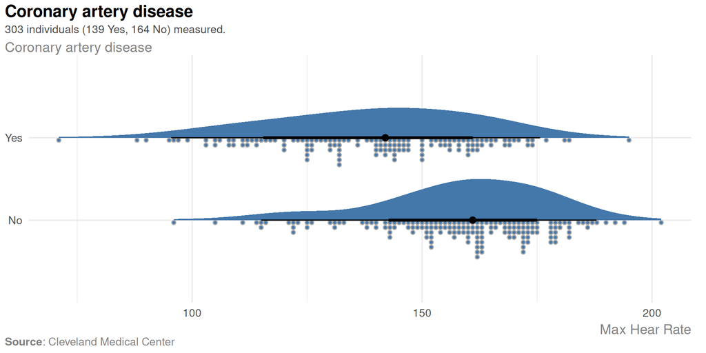

## What about this one?

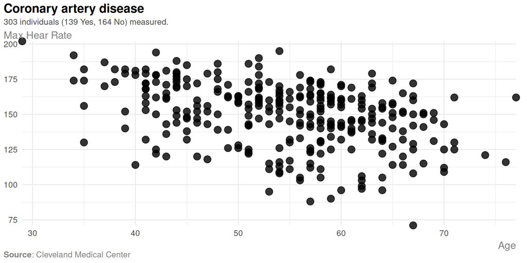

## What can we learn from data?

- We saw how max heart rate vary between patients having coronary artery disease…
- We saw how max heart rate change across peoples age…
- Now, could it just be that the patients with coronary artery disease are older?
- **Let’s make a plot and check together!**

## Open your Rstudio

[figure not shown]

## Exploring the Heart Disease dataset

1. Go to [**https://danmazjen.github.io/medicinsk-statistik**](https://danmazjen.github.io/medicinsk-statistik), exercises, and find the Cleveland Heart Disease dataset
2. Copy the following code:

```r
hd_data <- medisr::hd_data
# or if you didn't manage to download the medisr package yet:
hd_data <- readr::read_csv("https://www.statlearning.com/s/Heart.csv")
```

3. Paste it into your R console and check if you see the data in your `variable` pane.

## Code-along

```r
library(ggplot2)

hd_data
```

**1**

Tell R you will be using the `ggplot2` package

**2**

Take `hd_data`, and then,

## Code-along

```r
library(ggplot2)

hd_data |>
  ggplot(
    aes(x = HD, y = Age)
    ) +
  geom_boxplot()
```

**1**

Tell R you will be using the `ggplot2` package

**2**

Take `hd_data`, and then,

**3**

Make a `ggplot` skeleton

**4**

Select the x and y variables using `aes` (aestetics)

**5**

End the ggplot function that has a parenthesis open. Add `+` more…

**6**

Specify the type of plot you want `ggplot` to do with the skeleton

## You made your first plot with R code! 🎉🥳

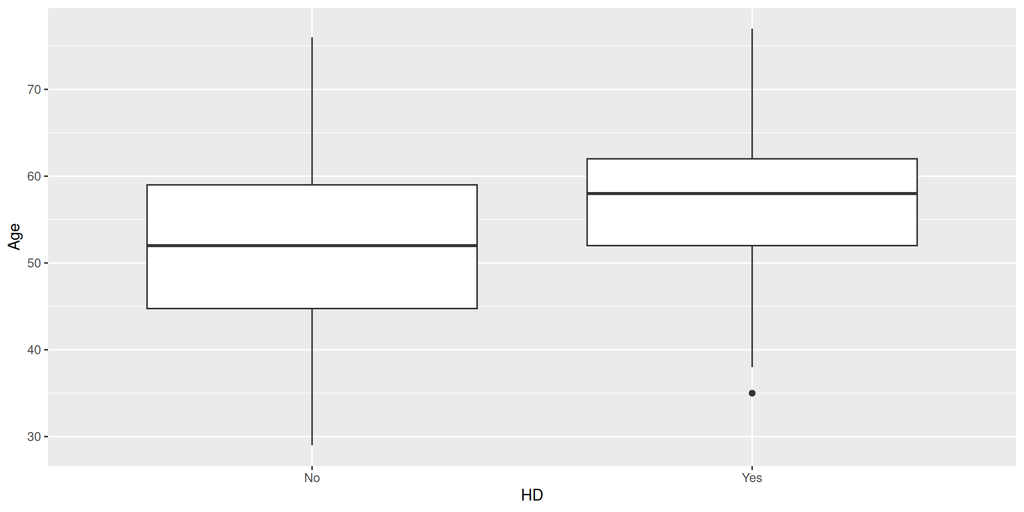

# Medical Statistics

In this course, we will

- develop statistical literacy skills
- Learn to make medical inference from statistics
- Perform statistics with the help of **R**

## Develop statistical literacy skills

- Interpret results from medical studies (e.g. *p*-values, confidence intervals, effect sizes)
- Critically evaluate claims in clinical research and media
- Identify common statistical pitfalls and misleading conclusions

## Learn to make medical inference from statistics

- Translate statistical results into clinically meaningful conclusions
- Understand uncertainty and variability in patient outcomes
- Statistical significance does not equal clinical importance — ask whether the result would actually change patient care

## Perform statistics using R

- Plotting data using `ggplot2` as you’ve already experienced
- Run statistical tests such as t-test, regression, etc.
- Read and understand the `R` output

[figure not shown]

## 🙋‍♀️ How many have read results in a paper and wondered what the numbers actually mean?

## 🙋‍♀️ How many have wondered how scientists make predictions for future disease probabilities?

## 🙋‍♀️ Would you be interested in learning how to navigate scientific claims based on data?

## This course is for you 🎉

## 🚶🚶‍♀️ Do you have coding/programming experience?

Never <——-> I took a course in computer science

## 🚶🚶‍♀️ Are you scared of statistics?

Not at all <——-> I had nightmares about this course already

## 🚶🚶‍♀️ How good are you right now at statistics?

Ronald Fisher level <——-> Who is Ronald Fisher?

## 🚶🚶‍♀️ How high expectations do you have for yourself in this course?

I want to learn everything <——-> I don’t mind failing 1st time

## The program for today:

Rest of the day: *learning the basics of R for medical statistics*

- If you don’t have R installed yet - no break for you, sorry 👀
- If you need help, grab hold of a teacher

Otherwise — 10 minutes break now!

[figure not shown]

# RStudio IDE

RStudio is a window that helps us navigate in R.

[figure not shown]

## Setup and layout

**General RStudio Options**

- Tools >> Global Options
  - > General Save Workspace to .RData on exit (never)
- Tools >> Global Options >> Code
  - > Editing: Use native pipe operator
  - > Saving: Automatically save when editor loses focus

## Rest of session

See the website chapter [11.4](https://danmazjen.github.io/medicinsk-statistik/sessions/session01.html#sec-setup-project)

A gentle introduction to **R**